# ECON 3880: Assignment 1

Samuel Morency - 101065894

2023-05-23

## Question 1

> Create a histogram chart for the variable **charges** and color them **blue** and fill in **red**.

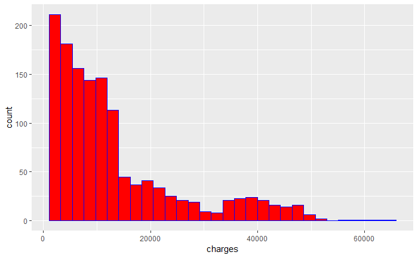

```r
library(tidyverse)
library(ggplot2)

df <- read.csv("insurance.csv", header = TRUE)

factorCols <- c("sex","children","smoker","region")
df[factorCols] <- lapply(df[factorCols], as.factor)

ggplot(df, aes(charges)) +
  geom_histogram(color = "blue",
                 fill = "red")
```

## Question 2

> Repeat the above plot again but instead of a histogram, create density plots and fill them according to the variable **Smoker** and also use the argument **alpha = 0.5** to make the densities transparent.

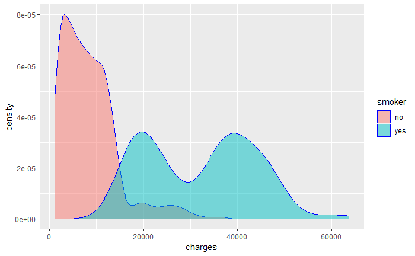

```r
ggplot(df, aes(charges, fill = smoker)) +
  geom_density(color = "blue",
               alpha = 0.5)
```

> Is there any differences between smokers and non-smokers?

The charges for smokers are significantly higher compared to non-smokers, at least 2-4 times larger.

## Question 3

> Is there any regional differences in density curves of **charges** among **smokers** and **nonsmokers**? To show these differences create a graph and explain if you see any differences.

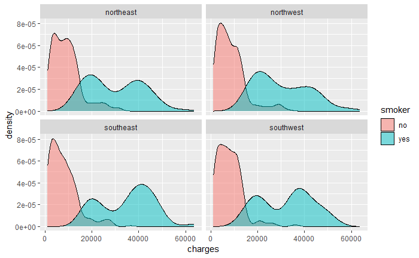

```r
ggplot(df, aes(charges, fill = smoker)) +
  geom_density(alpha = 0.5) +
  facet_wrap(~region)
```

While the positions on the x-axis appear to be largely the same, the height of the density peaks on the y-axis appear to be different. Most interestingly, out of the two peaks for smokers, the left peak is higher in the north, while the right-most peak is higher in the south.

## Question 4

> Install a package called **ggthemes** and load it into R. Next, create a boxplot chart for **Charges** and fill them based on **Smoker** and show the regional differences. Then, flip the axes and also change the theme to economist, which is included in the **ggtheme** package.

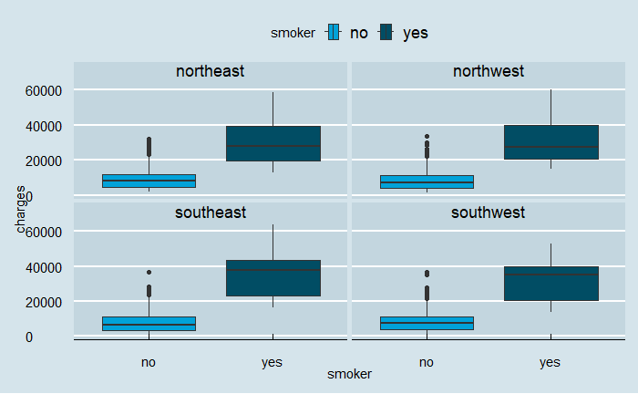

```r
library(ggthemes)

ggplot(df, aes(charges, smoker, fill = smoker)) +
  geom_boxplot() +
  facet_wrap(~region) +
  coord_flip() +
  theme_economist(dkpanel = TRUE) +
  scale_fill_economist()
```

## Question 5

> Create a **boxplot** chart to examine the link between **sex** and **charges** and fill them according to **smoker**.

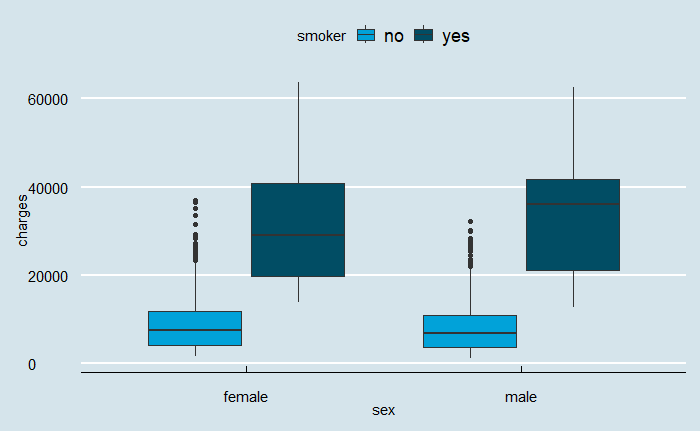

```r
ggplot(df, aes(sex, charges, fill = smoker)) +
  geom_boxplot() +
  theme_economist() +
  scale_fill_economist()
```

> Next, use the same variables and create a **violin** plot instead.

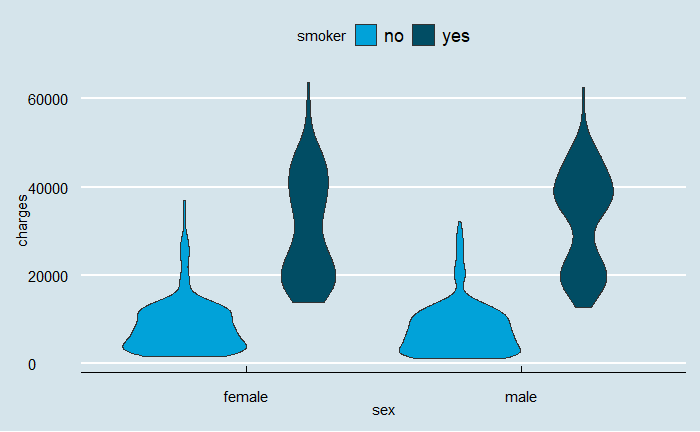

```r
ggplot(df, aes(sex, charges, fill = smoker)) +
  geom_violin() +
  theme_economist() +
  scale_fill_economist()
```

> What does this graph show? What can be seen using this graph that is not observable in the boxplot?

This graph conveys similar information as the box plot, except it allows you to see the density distribution. The box plot only shows you summary statistics.